# Seaborn

### Seaborn

Seaborn is a Python data visualization library built on top of Matplotlib. It provides a high-level interface for drawing attractive and informative statistical graphics. Seaborn is well-suited for working with data frames from libraries like Pandas and comes with built-in functions to visualize complex relationships in datasets with fewer lines of code compared to Matplotlib.

Seaborn focuses on providing statistical graphics and is commonly used for exploring data patterns, trends, and distributions. It simplifies many tasks by automatically handling aesthetics like colors and styles, making it easier to produce informative visualizations with less manual configuration.

Seaborn vs. Matplotlib

```
Seaborn works on top of Matplotlib and simplifies the process of creating visually appealing and informative plots.
Seaborn is especially useful for statistical data visualization, making it easier to explore and understand data distributions, relationships, and trends.
While Matplotlib provides more customization options, Seaborn abstracts much of the complexity and is easier to use for standard data visualization tasks.
```

Built-in Themes

```
Seaborn comes with built-in themes for styling your plots, such as darkgrid, whitegrid, dark, white, and ticks
```

```python
import seaborn as sns
sns.set_theme(style='darkgrid')
```

Dataset-Oriented Plotting

```
Seaborn functions are built to work well with Pandas DataFrames and arrays. It has functions that can handle entire datasets and apply grouping and aggregation automatically.
```

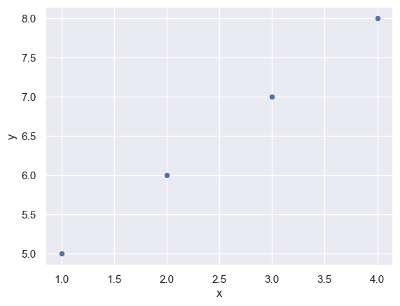

```python
import seaborn as sns
import pandas as pd

# Example using Pandas DataFrame
df = pd.DataFrame({'x': [1, 2, 3, 4], 'y': [5, 6, 7, 8]})
sns.scatterplot(data=df, x='x', y='y')
```

Plot Types in Seaborn

```
Relational Plots: Show relationships between variables.
scatterplot(): Creates scatter plots to show relationships between variables.
```

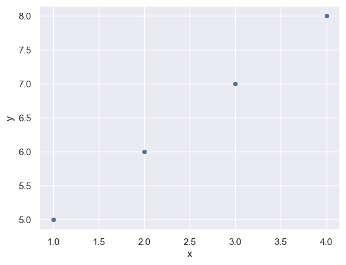

```python
sns.scatterplot(data=df, x='x', y='y')
```

```
lineplot(): Creates line plots for time series or trend analysis.
```

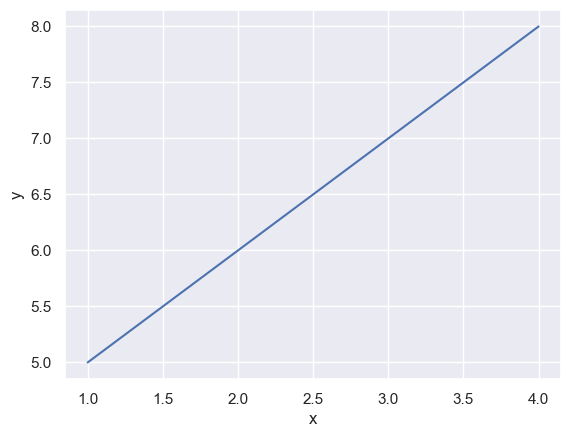

```python
sns.lineplot(data=df, x='x', y='y')
```

Categorical Plots: Visualize categorical data.

```
barplot(): Displays the relationship between a categorical variable and a continuous variable.
```

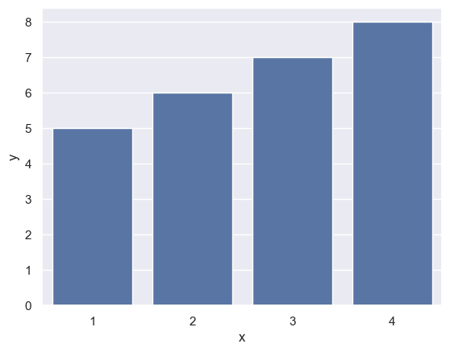

```python
sns.barplot(data=df, x='x', y='y')
```

```
boxplot(): Shows the distribution of quantitative data across different categories using boxes and whiskers.
```

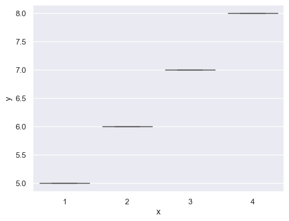

```python
sns.boxplot(data=df, x='x', y='y')
```

```
violinplot(): Combines the features of boxplot and KDE (Kernel Density Estimate) to provide more information about the distribution.
```

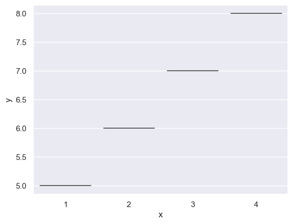

```python
sns.violinplot(data=df, x='x', y='y')
```

Distribution Plots: Show the distribution of data.

```
histplot(): Plots the histogram of a dataset.
```

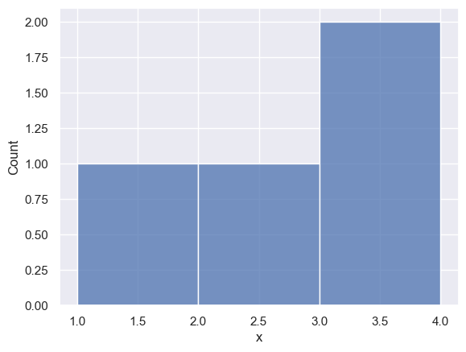

```python
sns.histplot(df['x'])
```

```
kdeplot(): Shows the probability density function (smoothed histogram).
```

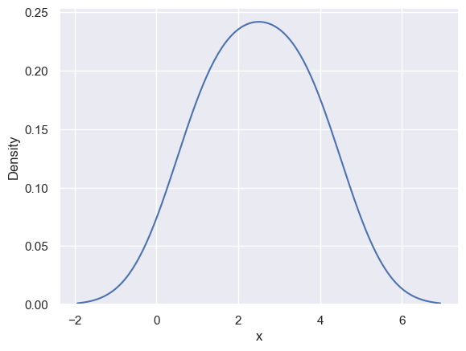

```python
sns.kdeplot(df['x'])
```

```
pairplot(): Automatically plots pairwise relationships between variables in a dataset, particularly useful for exploratory data analysis.
```

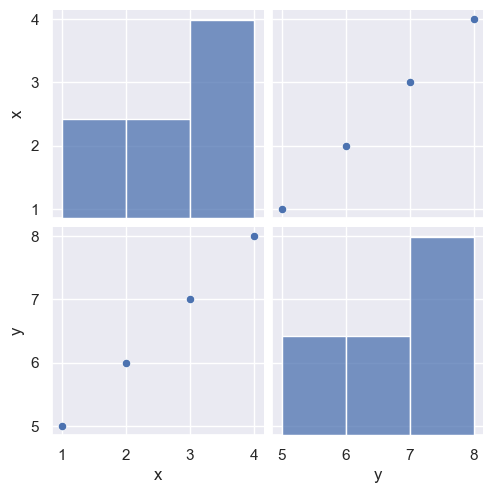

```python
sns.pairplot(df)
```

Heatmaps: Show matrix-like data.

```
heatmap(): Displays 2D matrix data (e.g., correlation matrices).
```

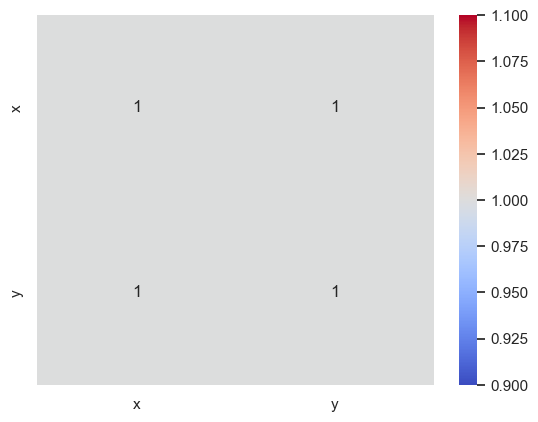

```python
sns.heatmap(df.corr(), annot=True, cmap='coolwarm')
```

Facet Grids

```
Seaborn supports creating facet grids, which are multiple plots separated by categories or levels of a variable. This is useful for visualizing how a variable behaves across multiple subcategories.
```

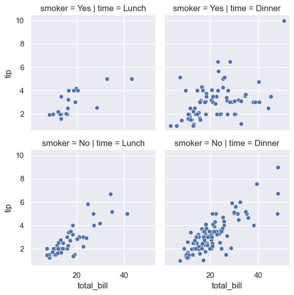

```python
tips = sns.load_dataset('tips')
g = sns.FacetGrid(tips, col="time", row="smoker")
g.map(sns.scatterplot, "total_bill", "tip")
```

Statistical Estimation

```
Many Seaborn plots automatically calculate statistics such as confidence intervals. For example, barplot() computes the mean of data by default and provides error bars
```

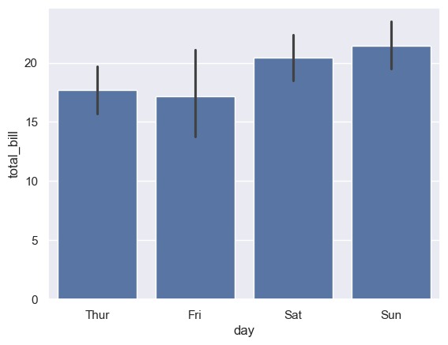

```python
sns.barplot(data=tips, x='day', y='total_bill')
```

Visualizing Correlations

```
Seaborn makes it easy to visualize correlations between variables using heatmaps
```

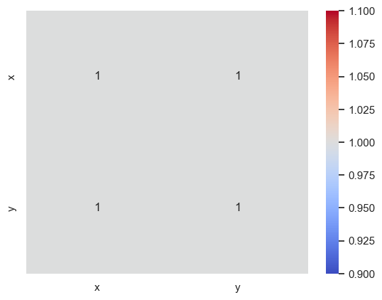

```python
corr = df.corr()
sns.heatmap(corr, annot=True, cmap='coolwarm')
```

Advanced Customization

```
You can still customize Seaborn plots using Matplotlib functions if you need more control
```

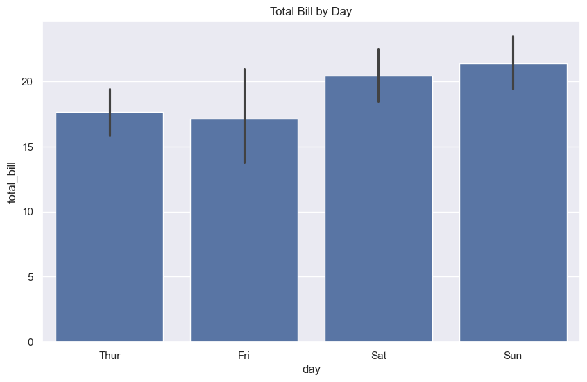

```python
import matplotlib.pyplot as plt
plt.figure(figsize=(10, 6))
sns.barplot(data=tips, x='day', y='total_bill')
plt.title('Total Bill by Day')
plt.show()
```

Seaborn Built-in Datasets

```
Seaborn provides several built-in datasets for quick access to explore various plots. You can load a dataset using sns.load_dataset().
```

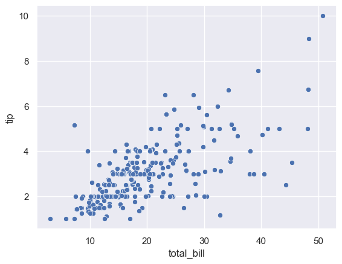

```python
tips = sns.load_dataset('tips')
sns.scatterplot(data=tips, x='total_bill', y='tip')
```

Possible Interview Questions on Seaborn

1. What is Seaborn, and how does it differ from Matplotlib?

   ```
    Seaborn is a data visualization library built on top of Matplotlib. It provides a high-level interface for creating attractive and informative statistical plots. Seaborn simplifies the process of creating complex visualizations and works well with Pandas DataFrames, while Matplotlib is more general-purpose and offers more detailed customization.
   ```

2. What are some common plot types you can create using Seaborn?

   ```
    Some common plot types in Seaborn include:
        scatterplot(): Scatter plot
        lineplot(): Line plot
        barplot(): Bar plot
        boxplot(): Box plot
        violinplot(): Violin plot
        histplot(): Histogram
        heatmap(): Heatmap
   ```

3. What is the difference between scatterplot() and lineplot() in Seaborn?

   ```
    scatterplot() is used to display individual data points as dots, whereas lineplot() connects data points with lines, making it suitable for time series or trend analysis.
   ```

4. How can you customize the style of Seaborn plots?

   ```
    You can customize the style of Seaborn plots by using the set_theme() function. Seaborn provides built-in themes like darkgrid, whitegrid, dark, white, and ticks.
        sns.set_theme(style='whitegrid')
   ```

5. How do you visualize the relationship between two variables in Seaborn?

   ```
    You can visualize the relationship between two variables using functions like scatterplot() for a scatter plot or lineplot() for a line plot.
        sns.scatterplot(data=df, x='x', y='y')
   ```

6. What is a FacetGrid in Seaborn, and when would you use it?

   ```
    A FacetGrid in Seaborn allows you to create multiple subplots for different subsets of your data based on the values of one or more categorical variables. It is useful for visualizing relationships between variables across different subcategories.
        g = sns.FacetGrid(tips, col="time", row="smoker")
        g.map(sns.scatterplot, "total_bill", "tip")
   ```

7. How do you create a heatmap using Seaborn?

   ```
    You can create a heatmap using the heatmap() function, which is useful for visualizing matrix-like data such as correlation matrices.
        sns.heatmap(df.corr(), annot=True, cmap='coolwarm')
   ```

8. What is the role of statistical estimation in Seaborn plots?

   ```
    Seaborn functions like barplot() and pointplot() automatically perform statistical estimation, such as computing the mean and confidence intervals for each category. You can customize this behavior using the estimator parameter.
   ```

9. How can you visualize the distribution of a dataset in Seaborn?

   ```
    Seaborn provides several functions for visualizing the distribution of a dataset:
        histplot() for histograms.
        kdeplot() for kernel density estimates.
        boxplot() and violinplot() for visualizing distributions with categorical variables.
   ```

10. How do you create pair plots in Seaborn, and what are they used for?

    ```
    pairplot() is used to visualize pairwise relationships in a dataset. It automatically creates scatter plots for numeric variables and histograms along the diagonal
    ```

### Reference

```
ChatGPT
```